# Corpus Analysis Masterclass 3b

Mark Alfano

27 April 2025

# Set working directory

```r
setwd("~/Documents/Philosophy/Experimental/R")
```

# load required packages

```r
require(readtext)
require(quanteda)
require(quanteda.textplots)
require(quanteda.textstats)
require(quanteda.textmodels)
require(quanteda.dictionaries)
require(quanteda.corpora)
require(topicmodels)
require(dplyr)
require(tidyr)
require(tidytext)
require(ggplot2)
require(network)
require(igraph)
require(gridExtra)
library(lexicon)
library(reshape2)
library(stringi)
```

# Full-corpus analysis

## Read Nietzsche’s books into R and transform into a corpus

```r
nietzsche <- readtext("nietzsche/*")
nietzsche
```

```
## readtext object consisting of 15 documents and 0 docvars.
## # A data frame: 15 × 2
##   doc_id       text
##   <chr>        <chr>
## 1 1872 BT.txt  "\"\n \nDie Geb\"..."
## 2 1873 DS.txt  "\"\n \nUnzeitg\"..."
## 3 1874 HL.txt  "\"\n \nUnzeitg\"..."
## 4 1874 SE.txt  "\"\n \nUnzeitg\"..."
## 5 1876 RWB.txt "\"\n \nUnzeitg\"..."
## 6 1880 HH.txt  "\"\n \nMenschl\"..."
## # ℹ 9 more rows
```

```r
nietzsche_corpus <- corpus(nietzsche)
```

# Summarize the full corpus.

This reveals that there are, for example, 741 sentences in The Antichrist, 1854 sentences in Beyond Good and Evil, and 803 sentences in Schopenhauer as Educator

```r
summary(nietzsche_corpus)
```

```
## Corpus consisting of 15 documents, showing 15 documents:
##
##          Text Types Tokens Sentences
##   1872 BT.txt  8614  47991      1110
##   1873 DS.txt  6110  29651       825
##   1874 HL.txt  6288  31158       736
##   1874 SE.txt  6294  32772       803
##  1876 RWB.txt  5684  27731       603
##   1880 HH.txt 21257 192918      5813
##    1881 D.txt 12996  96536      3047
##    1885 Z.txt 10909 103229      5848
##  1886 BGE.txt 11058  70685      1854
##   1887 GM.txt  9339  55634      1230
##   1887 GS.txt 12890  92870      3097
##    1888 A.txt  5123  30160       741
##   1888 CW.txt  3275  14250       597
##   1888 EH.txt  6356  36120       977
##   1888 TI.txt  5765  31240      1023
```

This is a slightly annoying format because the date and book name are combined. Let’s split that column so that we can plot some yearly comparisons. We also have to coerce the new Year column to be numeric because otherwise R thinks it’s a string variable.

### Clean up corpus

```r
tokenInfo <- summary(nietzsche_corpus)
tokenInfo <- separate(tokenInfo,
                      Text,
                      c('Year', 'Book'))
tokenInfo$Year <- as.numeric(tokenInfo$Year)
```

## visualize word count, comparing different books

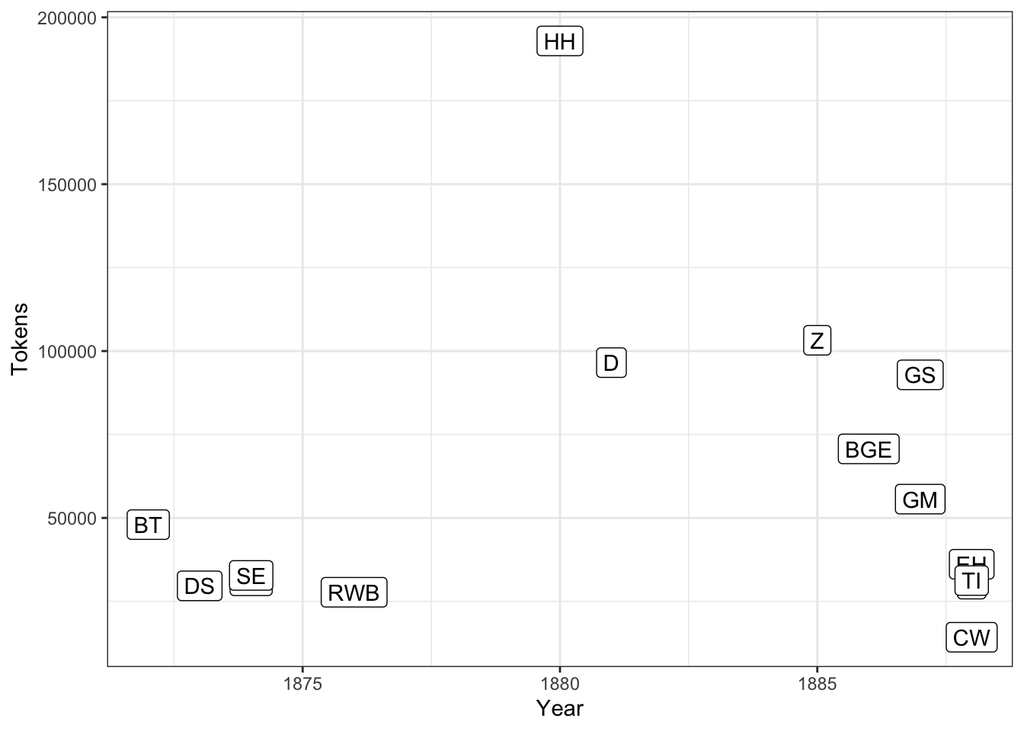

```r
ggplot(data=tokenInfo,
       aes(x = Year,
           y = Tokens,
           label = Book,
           group = 1)) +
  geom_point() +
  geom_label() +
  theme_bw()
```

## save the plot

```r
ggsave("nietzscheWC.tiff",
       plot = last_plot(),
       device = tiff,
       dpi = 300) # why 300 dots per inch?
```

## Tokenize the corpus, remove stopwords and punctuation, and get a list of the most common words

```r
toks_nietzsche <- tokens(nietzsche_corpus,
                         remove_punct = TRUE)
dfmat_nietzsche <- dfm(toks_nietzsche)
dfmat_nietzsche <- dfm_remove(dfmat_nietzsche,
                              pattern = stopwords("de")) # note that we are now removing DEUTSCH stopwords, rather than english, but because of changes in spelling in German from the 19th century to now, we will have to create a custom stopword dictionary as well
dfmat_nietzsche
```

```
## Document-feature matrix of: 15 documents, 49,778 features (83.94% sparse) and 0 docvars.
##               features
## docs           geburt tragödie griechenthum pessimismus neue ausgabe versuch
##   1872 BT.txt       7      147            1          14   31       1       4
##   1873 DS.txt       1        0            0           0   15       0       1
##   1874 HL.txt       0        1            0           0    6       0       3
##   1874 SE.txt       3        1            0           1   12       0       3
##   1876 RWB.txt      1        4            0           0   15       0       0
##   1880 HH.txt       4       17            0          11   70       3      10
##               features
## docs           selbstkritik friedrich nietzsche
##   1872 BT.txt             2         1         1
##   1873 DS.txt             0         2         1
##   1874 HL.txt             0         1         1
##   1874 SE.txt             0         2         1
##   1876 RWB.txt            0         1         1
##   1880 HH.txt             0         3         2
## [ reached max_ndoc ... 9 more documents, reached max_nfeat ... 49,768 more features ]
```

```r
topfeatures(dfmat_nietzsche, 20)
```

```
##       dass   menschen       mehr      immer      leben     selber     mensch
##       5515       2167       1669       1616       1371       1207       1095
##      giebt      macht       welt     gerade        art       zeit vielleicht
##       1076       1047        986        954        945        934        925
##         ja        wer        sei      schon      diess      kunst
##        887        853        834        831        761        740
```

## Remove custom stopwords as well

```r
custom_stop <- c("dass", "mehr", "immer", "ja", "wer", "sei", "diess")
dfmat_nietzsche <- dfm_remove(dfmat_nietzsche, pattern = custom_stop)
dfmat_nietzsche
```

```
## Document-feature matrix of: 15 documents, 49,771 features (83.95% sparse) and 0 docvars.
##               features
## docs           geburt tragödie griechenthum pessimismus neue ausgabe versuch
##   1872 BT.txt       7      147            1          14   31       1       4
##   1873 DS.txt       1        0            0           0   15       0       1
##   1874 HL.txt       0        1            0           0    6       0       3
##   1874 SE.txt       3        1            0           1   12       0       3
##   1876 RWB.txt      1        4            0           0   15       0       0
##   1880 HH.txt       4       17            0          11   70       3      10
##               features
## docs           selbstkritik friedrich nietzsche
##   1872 BT.txt             2         1         1
##   1873 DS.txt             0         2         1
##   1874 HL.txt             0         1         1
##   1874 SE.txt             0         2         1
##   1876 RWB.txt            0         1         1
##   1880 HH.txt             0         3         2
## [ reached max_ndoc ... 9 more documents, reached max_nfeat ... 49,761 more features ]
```

```r
topfeatures(dfmat_nietzsche, 20)
```

```
##    menschen       leben      selber      mensch       giebt       macht
##        2167        1371        1207        1095        1076        1047
##        welt      gerade         art        zeit  vielleicht       schon
##         986         954         945         934         925         831
##       kunst       seele    wahrheit     grossen         gut        eben
##         740         685         676         669         669         639
## zarathustra        erst
##         635         628
```

## Generate a word cloud

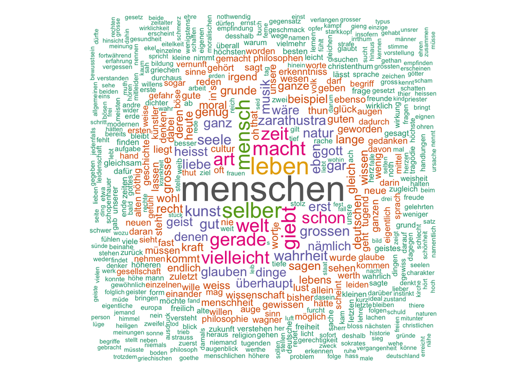

```r
set.seed(100)
textplot_wordcloud(dfmat_nietzsche,
                   min_count = 6,
                   random_order = FALSE,
                   rotation = .25,
                   color = RColorBrewer::brewer.pal(8, "Dark2")
                   )
```

## Run topic models using LDA

```r
set.seed(100)
if (require(topicmodels)) {
    my_lda_fit <- LDA(convert(dfmat_nietzsche,
                              to = "topicmodels"),
                      k = 8)
    get_terms(my_lda_fit, 10)
}
```

```
##       Topic 1      Topic 2        Topic 3      Topic 4     Topic 5
##  [1,] "menschen"   "musik"        "menschen"   "menschen"  "menschen"
##  [2,] "vielleicht" "wagner"       "art"        "leben"     "leben"
##  [3,] "giebt"      "kunst"        "giebt"      "gerade"    "gerade"
##  [4,] "ganz"       "tragödie"     "leben"      "strauss"   "mensch"
##  [5,] "kunst"      "welt"         "mensch"     "zeit"      "macht"
##  [6,] "zeit"       "mythus"       "vielleicht" "gar"       "zeit"
##  [7,] "ebenso"     "dionysischen" "moral"      "kultur"    "gar"
##  [8,] "leben"      "natur"        "macht"      "deutschen" "nämlich"
##  [9,] "wahrheit"   "leben"        "heute"      "ganz"      "art"
## [10,] "lassen"     "menschen"     "gerade"     "natur"     "vielleicht"
##       Topic 6      Topic 7    Topic 8
##  [1,] "menschen"   "menschen" "zarathustra"
##  [2,] "selber"     "selber"   "selber"
##  [3,] "leben"      "macht"    "oh"
##  [4,] "macht"      "welt"     "menschen"
##  [5,] "vielleicht" "art"      "sprach"
##  [6,] "giebt"      "mensch"   "liebe"
##  [7,] "art"        "leben"    "gleich"
##  [8,] "gerade"     "cultur"   "wahrlich"
##  [9,] "welt"       "natur"    "schon"
## [10,] "mensch"     "gerade"   "leben"
```

## To go beyond analyzing the whole corpus as a mass, we can also get the top features of each book

```r
topfeatures(dfmat_nietzsche,
            10,
            decreasing = TRUE,
            groups = docnames(dfmat_nietzsche)
            )
```

```
## $`1872 BT.txt`
##        musik     tragödie        kunst         welt dionysischen       mythus
##          167          147          124          113           89           79
##        natur     menschen        leben    euripides
##           77           72           70           59
##
## $`1873 DS.txt`
##    strauss          s     kultur  deutschen  philister     gerade    glauben
##        145         76         57         50         45         43         38
##       eben      recht vielleicht
##         37         36         35
##
## $`1874 HL.txt`
##      leben       zeit   menschen   historie geschichte     mensch        gar
##        117         81         80         79         55         53         52
##    bildung     gerade      macht
##         50         44         43
##
## $`1874 SE.txt`
##     menschen        leben       gerade         zeit  philosophie       mensch
##          129           77           68           67           64           57
##          gar schopenhauer        natur  philosophen
##           56           54           54           52
##
## $`1876 RWB.txt`
##    kunst   wagner    musik menschen    leben   selber   gerade künstler
##      108       84       67       64       53       50       47       46
##     ganz    macht
##       41       40
##
## $`1880 HH.txt`
##   menschen     selber      leben      giebt      kunst       zeit     mensch
##        585        267        259        247        238        236        227
##      macht       welt vielleicht
##        225        209        201
##
## $`1881 D.txt`
##   menschen     selber      macht      giebt     gerade vielleicht      leben
##        261        207        156        134        122        113        111
##        art     unsere       welt
```

[output cut: 34 more lines]

```
##       140        64        39        26        26        22        22        19
##    erlöst      fall
##        19        19
##
## $`1888 EH.txt`
## zarathustra       leben   deutschen         art      wagner       giebt
##          71          63          58          50          48          47
##        wort     begriff  vielleicht      mensch
##          47          47          46          43
##
## $`1888 TI.txt`
##    leben      art    moral   mensch    giebt menschen   lebens    heute
##       67       66       58       56       54       47       45       42
##     welt    bloss
##       42       39
```

## Use hierarchical clustering to establish the pairwise similarity of all books, then plot the results as a dendrogram.

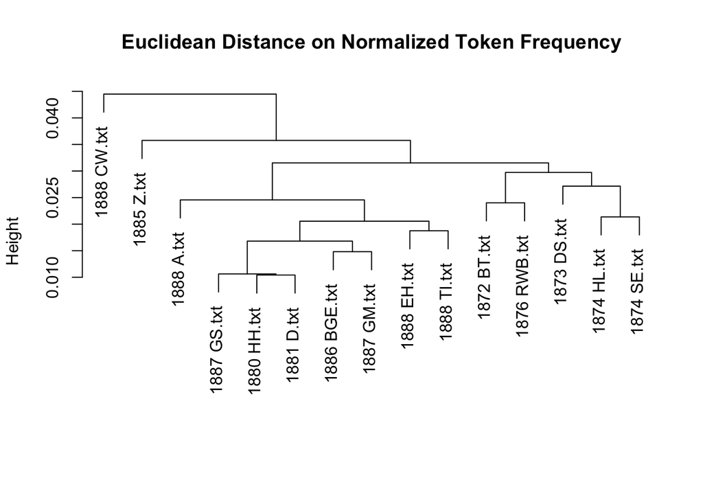

```r
tstat_dist <- textstat_dist(dfm_weight(dfmat_nietzsche,
                                       scheme = "prop"))
nietzsche_cluster <- hclust(as.dist(tstat_dist))
nietzsche_cluster$labels <- docnames(dfmat_nietzsche)
plot(nietzsche_cluster, xlab = "", sub = "",
     main = "Euclidean Distance on Normalized Token Frequency")
```

## comparison wordclouds of Nietzsche’s first seven books, and another of the next eight

(8 is the maximum that can be plotted in a single word cloud)

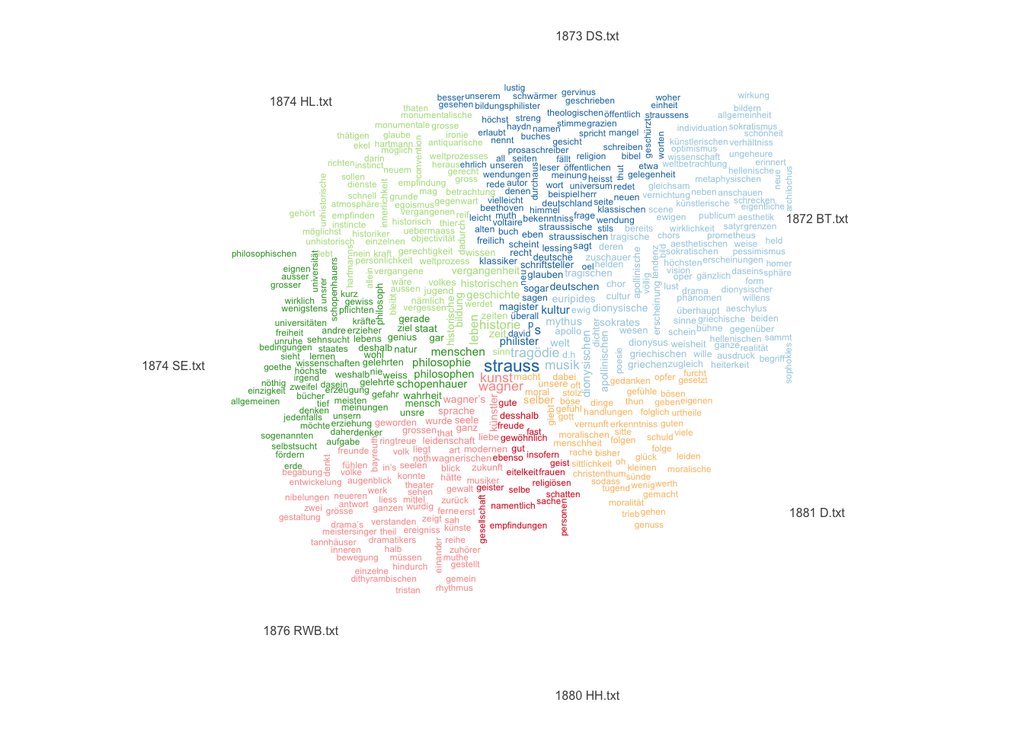

```r
dfmat_nietzsche1 <- dfmat_nietzsche[1:7,]
textplot_wordcloud(dfmat_nietzsche1, max_size = 1, labelsize = .5, comparison = TRUE, labeloffset = .05)
```

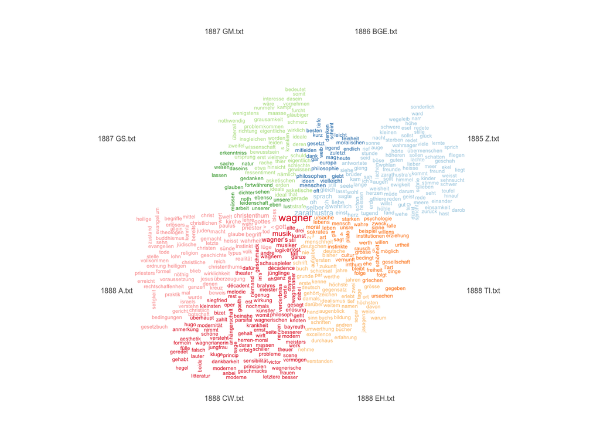

```r
dfmat_nietzsche2 <- dfmat_nietzsche[8:15,]
textplot_wordcloud(dfmat_nietzsche2, max_size = 1, labelsize = .5, comparison = TRUE, labeloffset = .05)
```

# Lexical dispersion plots

## Nietzsche on ‘shame’ [‘schand*’, ’schmach*’, ’scham*’]

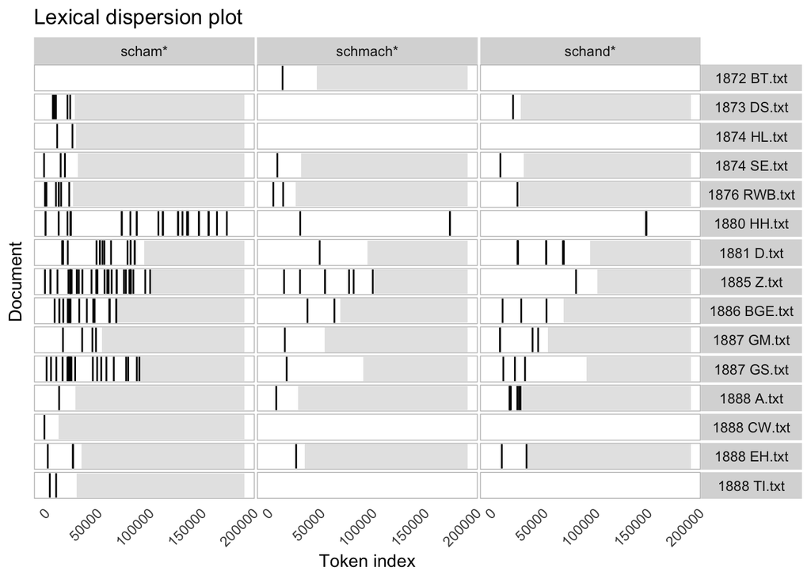

```r
scham_kwic <- kwic(tokens(nietzsche_corpus), pattern = "scham*")
schamch_kwic <- kwic(tokens(nietzsche_corpus), pattern = "schmach*")
schand_kwic <- kwic(tokens(nietzsche_corpus), pattern = "schand*")

shame <- textplot_xray(scham_kwic,
                       schamch_kwic,
                       schand_kwic,
                       scale = "absolute", # what happens when we use 'relative' instead?
                       sort = TRUE) +
  theme(axis.text.x = element_text(angle = 45, hjust=1)) +
  theme(axis.text.y = element_blank(),
        axis.ticks.y = element_blank(),
        axis.ticks.x = element_blank())
shame
```

## Nietzsche on ‘style’ [‘stil’, ‘stile’, ‘stils’]

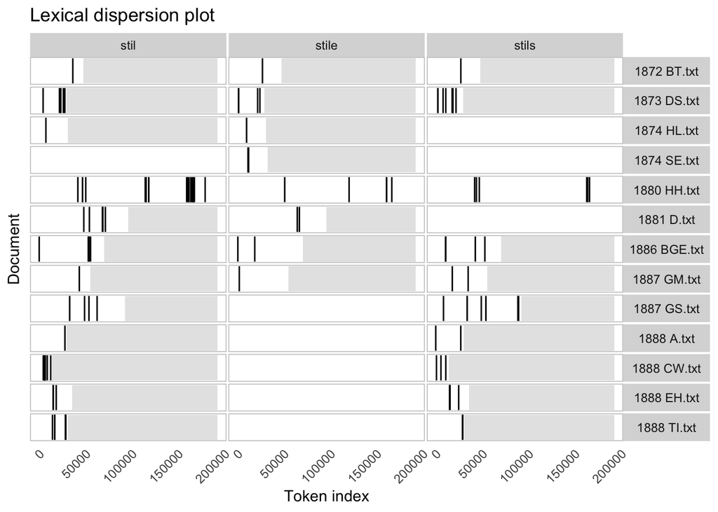

```r
stil_kwic <- kwic(tokens(nietzsche_corpus), pattern = "stil")
stile_kwic <- kwic(tokens(nietzsche_corpus), pattern = "stile")
stils_kwic <- kwic(tokens(nietzsche_corpus), pattern = "stils")

style <- textplot_xray(stil_kwic,
                       stile_kwic,
                       stils_kwic,
                       scale = "absolute",
                       sort = TRUE) + # what happens when we use sort = FALSE?
  theme(axis.text.x = element_text(angle = 45, hjust=1)) +
  theme(axis.text.y = element_blank(),
        axis.ticks.y = element_blank(),
        axis.ticks.x = element_blank())
style
```

## Nietzsche on ‘virtue’ [’tugend*’]

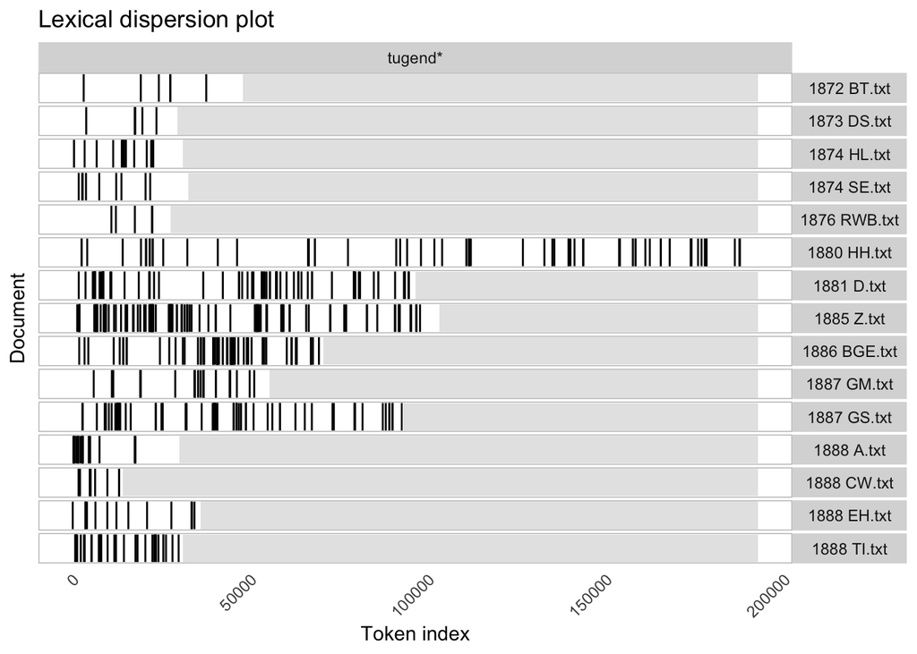

```r
virtue_kwic <- kwic(tokens(nietzsche_corpus), pattern = "tugend*")

virtue <- textplot_xray(virtue_kwic,
                        scale = "absolute",
                        sort = TRUE) +
  theme(axis.text.x = element_text(angle = 45, hjust=1)) +
  theme(axis.text.y = element_blank(),
        axis.ticks.y = element_blank(),
        axis.ticks.x = element_blank())
virtue
```

## save the plot

```r
ggsave("nietzschevirtue.tiff",
       plot = last_plot(),
       device = tiff,
       dpi = 300,
       bg = "white") # why a white background?
```

## Nietzsche on ‘trust’ [’vertrau*’] and ‘mistrust’ [’misstrau*’]

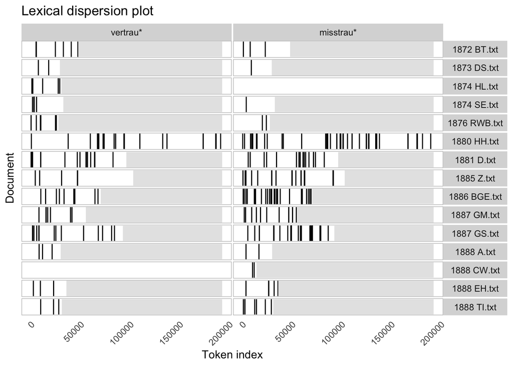

```r
vertrau_kwic <- kwic(tokens(nietzsche_corpus), pattern = "vertrau*")
misstrau_kwic <- kwic(tokens(nietzsche_corpus), pattern = "misstrau*")

trust <- textplot_xray(vertrau_kwic,
                       misstrau_kwic,
                       scale = "absolute",
                       sort = TRUE) +
  theme(axis.text.x = element_text(angle = 45, hjust=1)) +
  theme(axis.text.y = element_blank(),
        axis.ticks.y = element_blank(),
        axis.ticks.x = element_blank())
trust
```

## Nietzsche on ‘kultur’ [’kultur*’] and ‘cultur’ [’cultur*’]

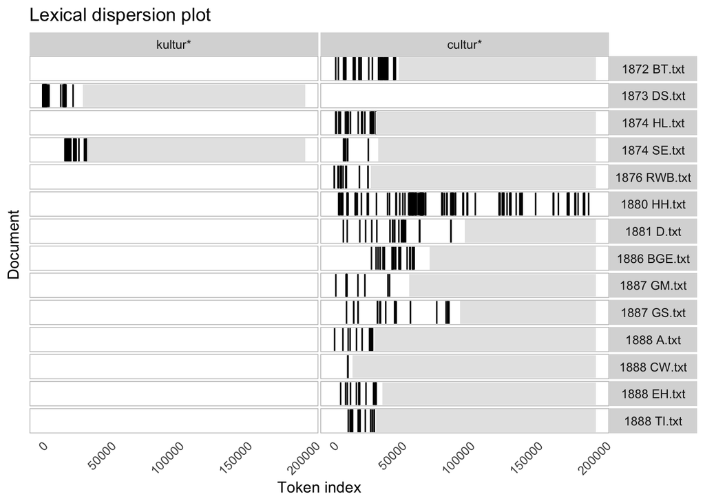

```r
kultur_kwic <- kwic(tokens(nietzsche_corpus), pattern = "kultur*")
cultur_kwic <- kwic(tokens(nietzsche_corpus), pattern = "cultur*")

culture <- textplot_xray(kultur_kwic,
                         cultur_kwic,
                         scale = "absolute",
                         sort = TRUE) +
  theme(axis.text.x = element_text(angle = 45, hjust=1)) +
  theme(axis.text.y = element_blank(),
        axis.ticks.y = element_blank(),
        axis.ticks.x = element_blank())
culture
```

# LIWCalike analysis

Next, we can examine moral psychological terms using LIWCalike

## Load dictionary and run function:

```r
nietzschedic <- dictionary(file = "nietzsche.dic")
```

```
## note: ignoring undefined categories:
```

```
##   119 for verges*
```

```
## note: removing empty key: forgetting
```

```r
LIWCanalysis_nietzsche <- liwcalike(nietzsche_corpus, nietzschedic)
```

### clean up LIWCalike output

```r
LIWCanalysis_nietzsche <- separate(LIWCanalysis_nietzsche, docname, c('Year', 'Book', 'Filler'))
```

### Further cleaning

```r
LIWCanalysis_nietzsche <- LIWCanalysis_nietzsche %>% mutate_at(c(9:72), as.numeric)
```

### Old way of doing it, very clunky

```r
LIWCanalysis_nietzsche$Sixltr <- as.numeric(as.character(LIWCanalysis_nietzsche$Sixltr))
LIWCanalysis_nietzsche$instinct <- as.numeric(as.character(LIWCanalysis_nietzsche$instinct))
LIWCanalysis_nietzsche$shame <- as.numeric(as.character(LIWCanalysis_nietzsche$shame))
LIWCanalysis_nietzsche$style <- as.numeric(as.character(LIWCanalysis_nietzsche$style))
LIWCanalysis_nietzsche$virtue <- as.numeric(as.character(LIWCanalysis_nietzsche$virtue))
LIWCanalysis_nietzsche$culture <- as.numeric(as.character(LIWCanalysis_nietzsche$culture))
```

## Compare average length of sentences

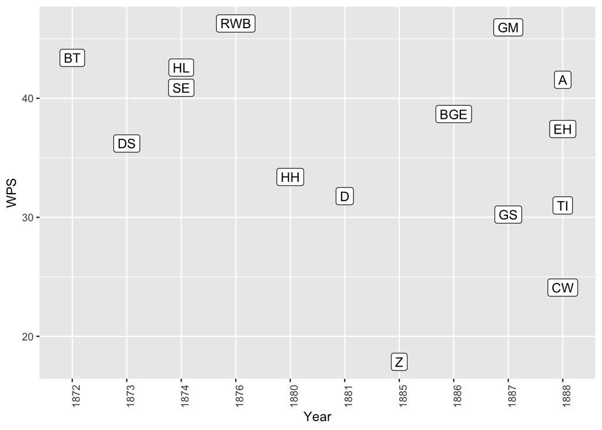

```r
ggplot(data=LIWCanalysis_nietzsche,
       aes(x = Year,
           y = WPS,
           label = Book)) +
  geom_point() +
  geom_label() +
  theme(axis.text.x = element_text(angle = 90))
```

## Compare frequency of long words

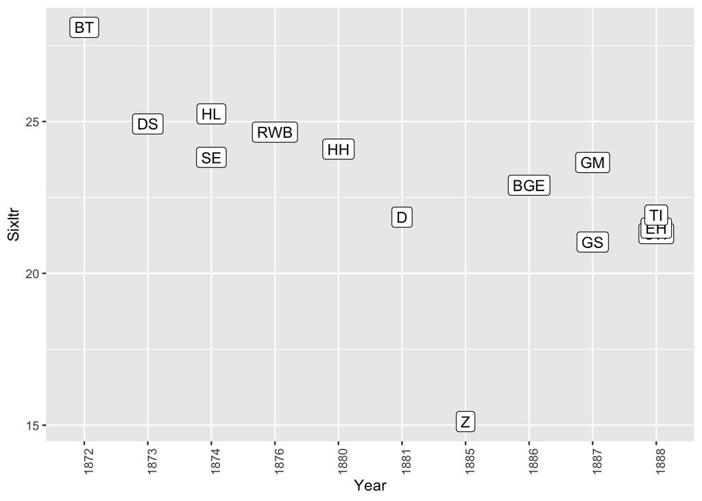

```r
ggplot(data=LIWCanalysis_nietzsche,
       aes(x = Year,
           y = Sixltr,
           label = Book)) +
  geom_point() +
  geom_label() +
  theme(axis.text.x = element_text(angle = 90))
```

## Compare frequency of ‘intinct’

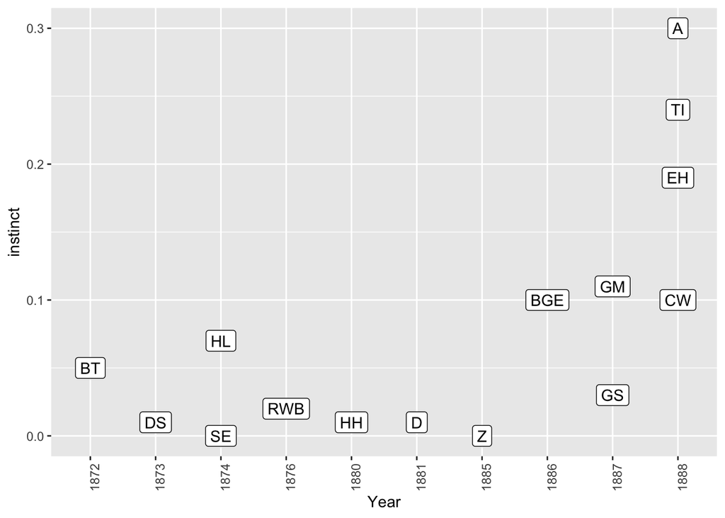

```r
ggplot(data=LIWCanalysis_nietzsche,
       aes(x = Year,
           y = instinct,
           label = Book)) +
  geom_point() +
  geom_label() +
  theme(axis.text.x = element_text(angle = 90))
```

## Compare frequency of ‘shame’

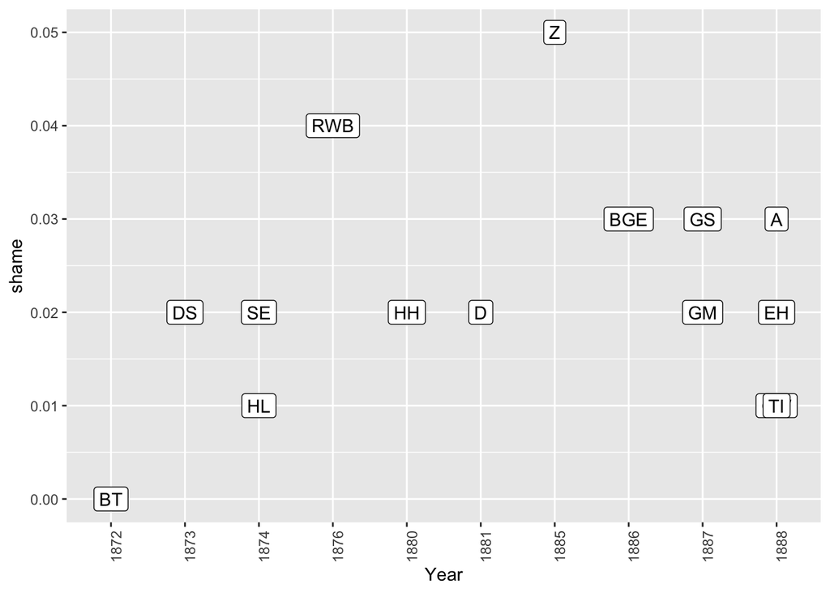

```r
ggplot(data=LIWCanalysis_nietzsche,
       aes(x = Year,
           y = shame,
           label = Book)) +
  geom_point() +
  geom_label() +
  theme(axis.text.x = element_text(angle = 90))
```

## Compare frequency of ‘style’

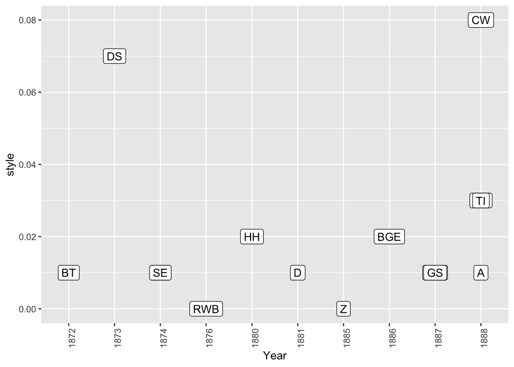

```r
ggplot(data=LIWCanalysis_nietzsche,
       aes(x = Year,
           y = style,
           label = Book)) +
  geom_point() +
  geom_label() +
  theme(axis.text.x = element_text(angle = 90))
```

## Compare frequency of ‘virtue’

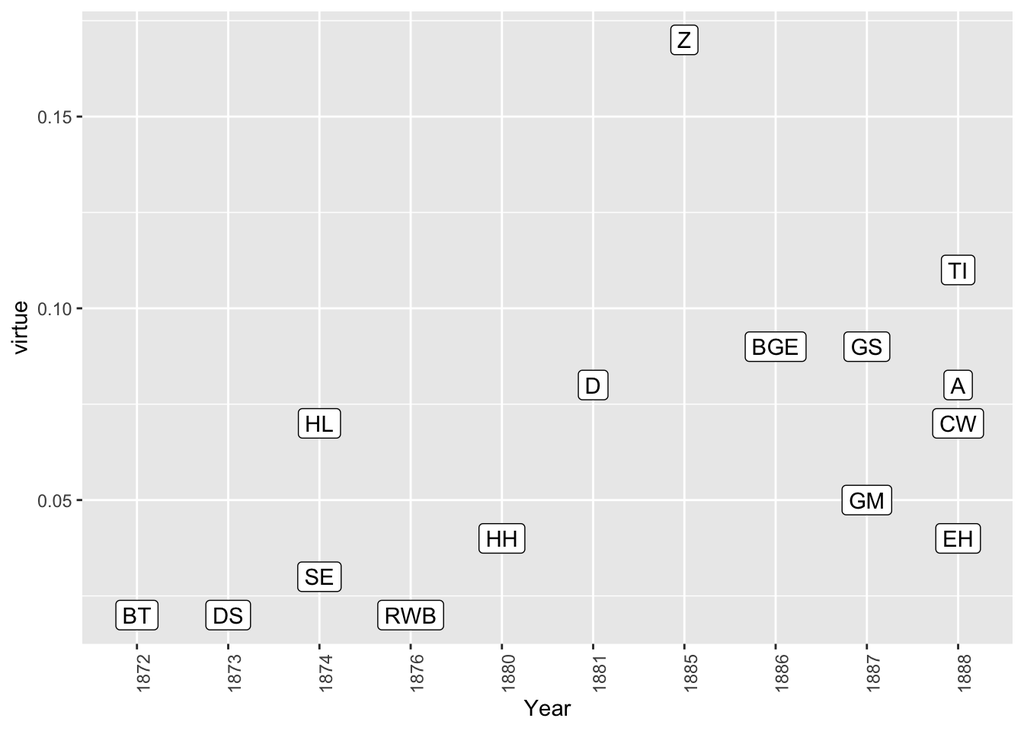

```r
ggplot(data=LIWCanalysis_nietzsche,
       aes(x = Year,
           y = virtue,
           label = Book)) +
  geom_point() +
  geom_label() +
  theme(axis.text.x = element_text(angle = 90))
```

## save the plot

```r
ggsave("nietzschevirt.tiff", plot = last_plot(), device = tiff, dpi = 300, bg = "white")
```

## Compare frequency of ‘culture’

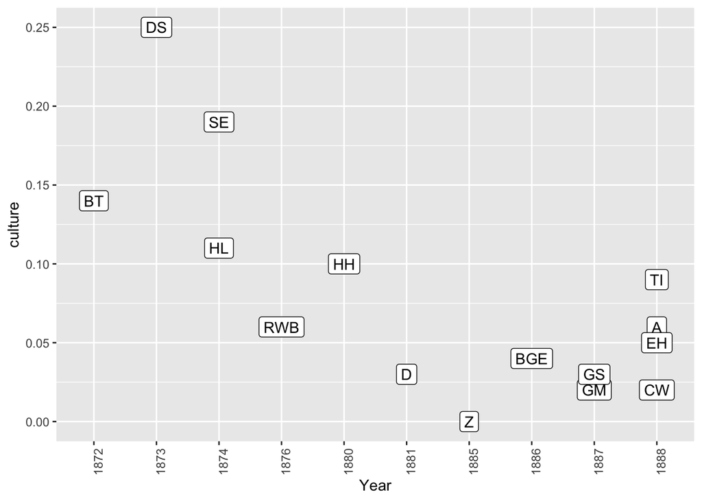

```r
ggplot(data=LIWCanalysis_nietzsche,
       aes(x = Year,
           y = culture,
           label = Book)) +
  geom_point() +
  geom_label() +
  theme(axis.text.x = element_text(angle = 90))
```

## Transform the LIWCalike output into an adjacency matrix. Then transform adjacency matrix into a network object with parameters for node strength and edge weight

```r
LIWCanalysis_nietzsche_simple <- LIWCanalysis_nietzsche[,9:60] #subset only the desired columns


M <- data.matrix(LIWCanalysis_nietzsche_simple) #transform to matrix
T <- t(M) #build transpose matrix
LIWCanalysis_nietzsche_adj <- (T %*% M) #MULTIPLY!

nietzsche_network <- graph_from_adjacency_matrix(LIWCanalysis_nietzsche_adj,
                                                 mode = "undirected",
                                                 weighted = TRUE,
                                                 diag = FALSE)

str <- strength(nietzsche_network)
V(nietzsche_network)$size <- str*4
E(nietzsche_network)$width <- E(nietzsche_network)$weight*4
```

## Plot the LIWCalike network using a circle layout.

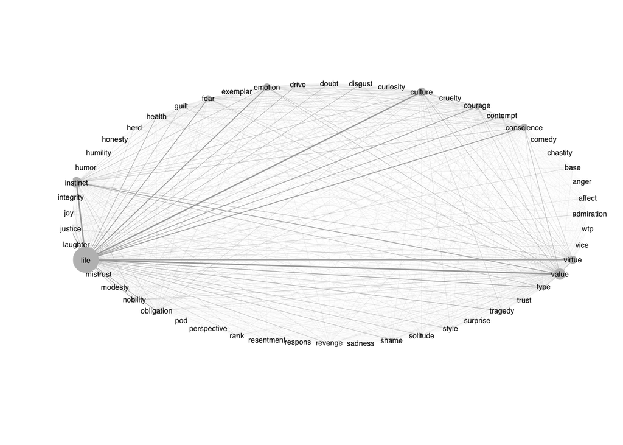

```r
l <- layout_in_circle(nietzsche_network)
l <- norm_coords(l,
                 ymin=-1,
                 ymax=1,
                 xmin=-2,
                 xmax=2)
plot.igraph(nietzsche_network,
            layout=l*1,
            vertex.color="gray",
            vertex.frame.color="gray",
            vertex.label.cex=.5,
            vertex.label.color="black",
            rescale=F,
            vertex.label.family = "Helvetica")
```

## Same thing, but now at the level of the paragraph rather than the book

```r
paragraphs <- corpus_reshape(nietzsche_corpus,
                             to = 'paragraphs')
head(paragraphs)
```

```
## Corpus consisting of 6 documents.
## 1872 BT.txt.1 :
## "Die Geburt der Tragödie. Oder: Griechenthum und Pessimismus."
##
## 1872 BT.txt.2 :
## "Neue Ausgabe mit dem Versuch einer Selbstkritik."
##
## 1872 BT.txt.3 :
## "Von Friedrich Nietzsche."
##
## 1872 BT.txt.4 :
## "Leipzig. Verlag von E. W. Fritzsch. 1878 [11872, 21874] Vers..."
##
## 1872 BT.txt.5 :
## "Was auch diesem fragwürdigen Buche zu Grunde liegen mag: es ..."
##
## 1872 BT.txt.6 :
## "Man erräth, an welche Stelle hiermit das grosse Fragezeichen..."
```

```r
nietzschedic <- dictionary(file = "nietzsche.dic")
```

```
## note: ignoring undefined categories:
```

```
##   119 for verges*
```

```
## note: removing empty key: forgetting
```

```r
LIWCanalysis_nietzsche_para <- liwcalike(paragraphs,
                                         nietzschedic)
```

```r
LIWCanalysis_nietzsche_para <- separate(LIWCanalysis_nietzsche_para,
                                        docname,
                                        c('Year', 'Book', 'Filler', 'Section'))
```

```r
LIWCanalysis_nietzsche_para_simple <- LIWCanalysis_nietzsche_para[,10:61]

M <- data.matrix(LIWCanalysis_nietzsche_para_simple)
T <- t(M)
LIWCanalysis_nietzsche_para_adj <- (T %*% M)

nietzsche_para_network <- graph_from_adjacency_matrix(LIWCanalysis_nietzsche_para_adj,
                                                      mode = "undirected",
                                                      weighted = TRUE,
                                                      diag = FALSE)

str <- strength(nietzsche_para_network)
V(nietzsche_para_network)$size <- str*.01
E(nietzsche_para_network)$width <- E(nietzsche_para_network)$weight*.01
```

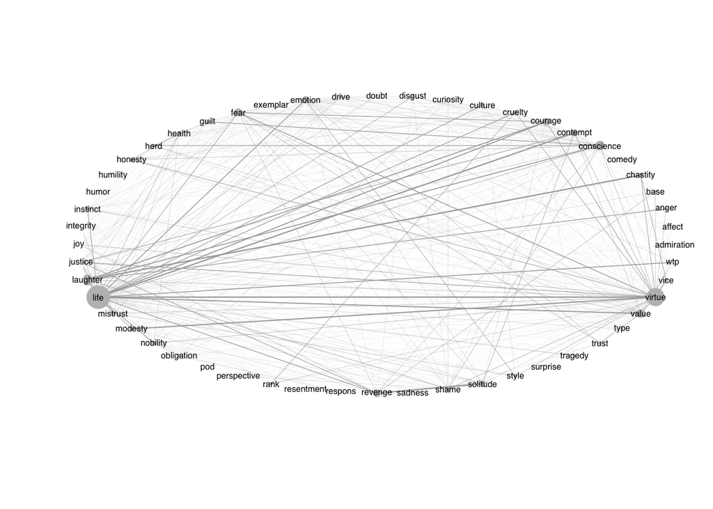

```r
l <- layout_in_circle(nietzsche_para_network)
l <- norm_coords(l,
                 ymin=-.5,
                 ymax=.5,
                 xmin=-1,
                 xmax=1)
plot.igraph(nietzsche_para_network,
            layout=l*2,
            vertex.color="gray",
            vertex.frame.color="gray",
            vertex.label.cex=.5,
            vertex.label.color="black",
            rescale=F,
            vertex.label.family = "Helvetica")
```

## paragraph-level egonet for ‘solitude’

subset the rows so that you only have ones where solitude > 0

```r
LIWCanalysis_solitude <- subset(LIWCanalysis_nietzsche_para_simple,
                                solitude > 0) #what's going on here??
```

```r
M <- data.matrix(LIWCanalysis_solitude)
T <- t(M)
LIWCanalysis_solitude_adj <- (T %*% M)

nietzsche_solitude_network <- graph_from_adjacency_matrix(LIWCanalysis_solitude_adj,
                                                          mode = "undirected",
                                                          weighted = TRUE,
                                                          diag = FALSE)

str <- strength(nietzsche_solitude_network)
V(nietzsche_solitude_network)$size <- str*.1
E(nietzsche_solitude_network)$width <- E(nietzsche_solitude_network)$weight*.05
```

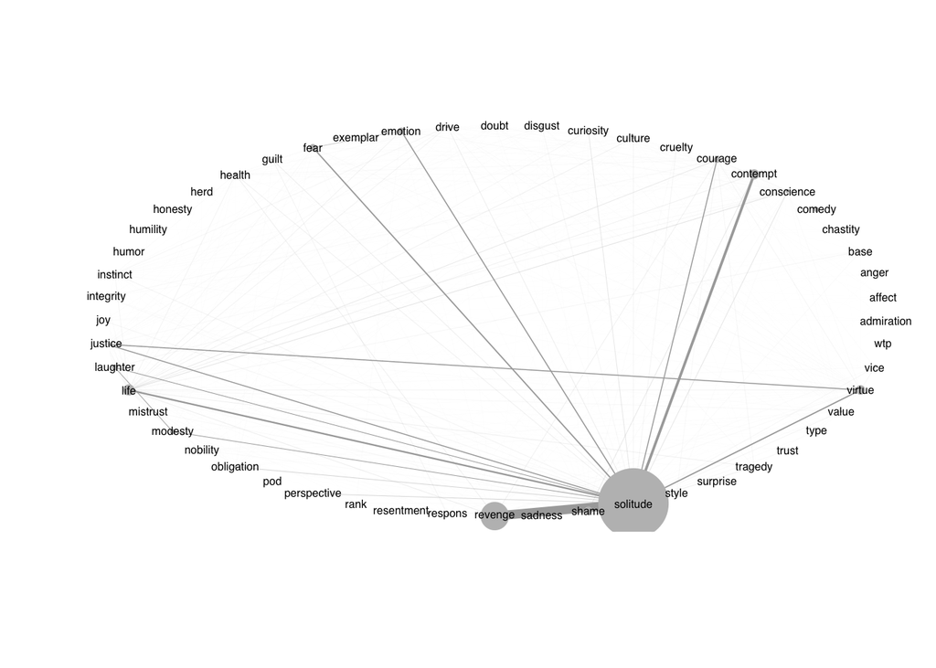

```r
l <- layout_in_circle(nietzsche_solitude_network)
l <- norm_coords(l,
                 ymin=-.5,
                 ymax=.5,
                 xmin=-1,
                 xmax=1)
plot.igraph(nietzsche_solitude_network,
            layout=l*2,
            vertex.color="gray",
            vertex.frame.color="gray",
            vertex.label.cex=.5,
            vertex.label.color="black",
            rescale=F,
            vertex.label.family = "Helvetica")
```

## paragraph-level egonet for ‘style’

```r
LIWCanalysis_style <- subset(LIWCanalysis_nietzsche_para_simple,
                             style > 0)
```

```r
M <- data.matrix(LIWCanalysis_style)
T <- t(M)
LIWCanalysis_style_adj <- (T %*% M)

nietzsche_style_network <- graph_from_adjacency_matrix(LIWCanalysis_style_adj,
                                                       mode = "undirected",
                                                       weighted = TRUE,
                                                       diag = FALSE)

str <- strength(nietzsche_style_network)
V(nietzsche_style_network)$size <- str*.2
E(nietzsche_style_network)$width <- E(nietzsche_style_network)$weight*.1
```

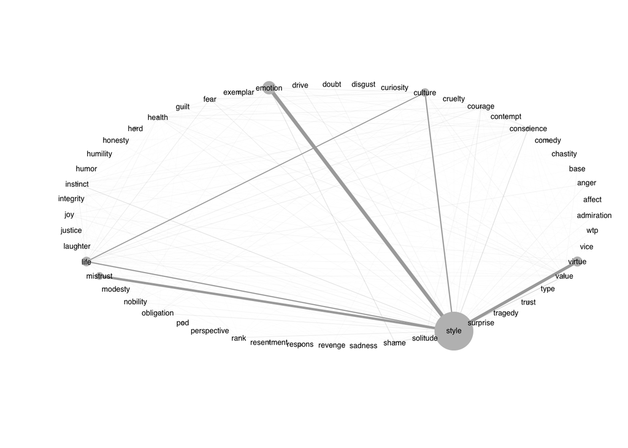

```r
l <- layout_in_circle(nietzsche_style_network)
l <- norm_coords(l,
                 ymin=-.5,
                 ymax=.5,
                 xmin=-1,
                 xmax=1)
plot.igraph(nietzsche_style_network,
            layout=l*2,
            vertex.color="gray",
            vertex.frame.color="gray",
            vertex.label.cex=.5,
            vertex.label.color="black",
            rescale=F,
            vertex.label.family = "Helvetica")
```

## paragraph-level egonet for ‘modesty’

Coerce the modesty column to numeric, then subset the rows so that you only have ones where modesty > 0

```r
LIWCanalysis_nietzsche_para_simple$modesty <- as.numeric(as.character(LIWCanalysis_nietzsche_para_simple$modesty))
LIWCanalysis_modesty <- subset(LIWCanalysis_nietzsche_para_simple,
                               modesty > 0)
```

```r
M <- data.matrix(LIWCanalysis_modesty)
T <- t(M)
LIWCanalysis_modesty_adj <- (T %*% M)

nietzsche_modesty_network <- graph_from_adjacency_matrix(LIWCanalysis_modesty_adj,
                                                         mode = "undirected",
                                                         weighted = TRUE,
                                                         diag = FALSE)

str <- strength(nietzsche_modesty_network)
V(nietzsche_modesty_network)$size <- str*.1
E(nietzsche_modesty_network)$width <- E(nietzsche_modesty_network)$weight*.05
```

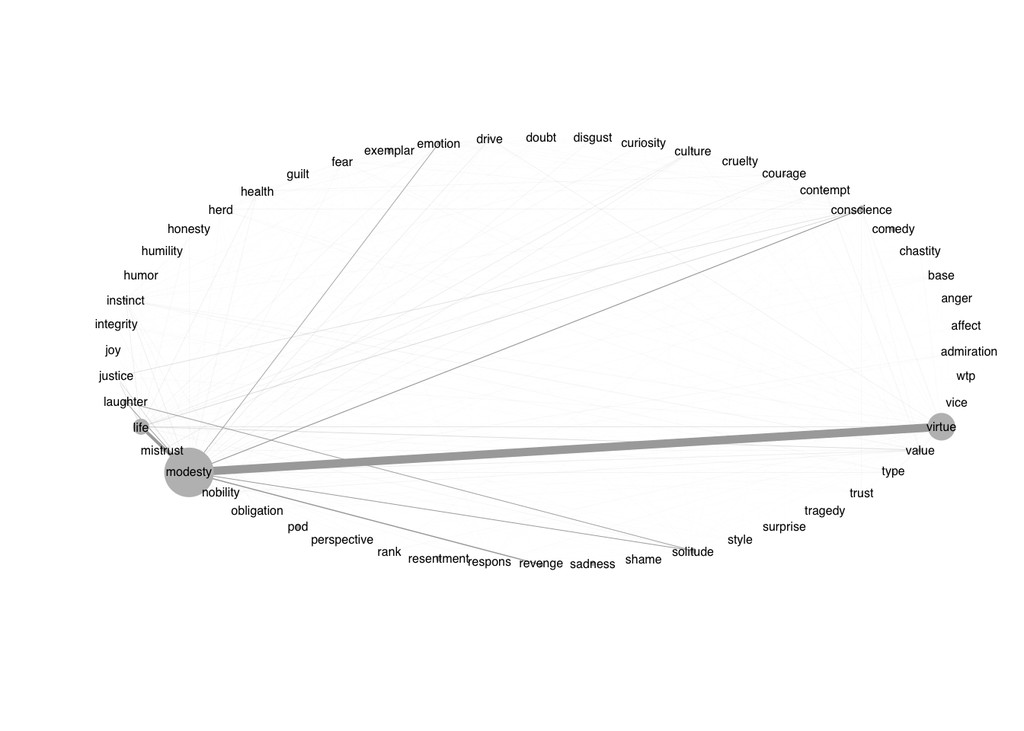

```r
l <- layout_in_circle(nietzsche_modesty_network)
l <- norm_coords(l,
                 ymin=-.5,
                 ymax=.5,
                 xmin=-1,
                 xmax=1)
plot.igraph(nietzsche_modesty_network,
            layout=l*2,
            vertex.color="gray",
            vertex.frame.color="gray",
            vertex.label.cex=.5,
            vertex.label.color="black",
            rescale=F,
            vertex.label.family = "Helvetica")
```

## paragraph-level egonet for ‘humility’

Coerce the humility column to numeric, then subset the rows so that you only have ones where humility > 0

```r
LIWCanalysis_nietzsche_para_simple$humility <- as.numeric(as.character(LIWCanalysis_nietzsche_para_simple$humility))
LIWCanalysis_humility <- subset(LIWCanalysis_nietzsche_para_simple,
                                humility > 0)
```

```r
M <- data.matrix(LIWCanalysis_humility)
T <- t(M)
LIWCanalysis_humility_adj <- (T %*% M)

nietzsche_humility_network <- graph_from_adjacency_matrix(LIWCanalysis_humility_adj,
                                                          mode = "undirected",
                                                          weighted = TRUE,
                                                          diag = FALSE)

str <- strength(nietzsche_humility_network)
V(nietzsche_humility_network)$size <- str*2
E(nietzsche_humility_network)$width <- E(nietzsche_humility_network)$weight*1.5
```

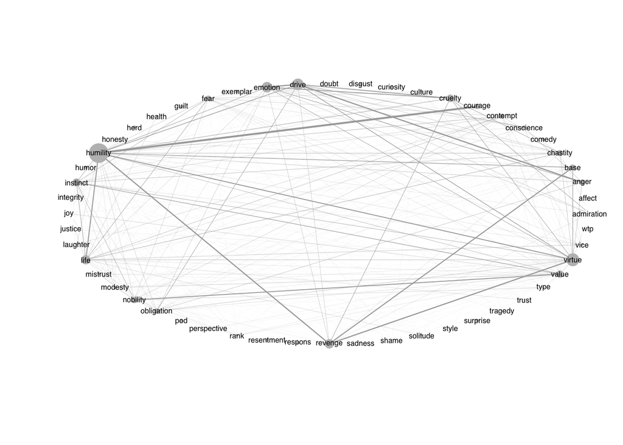

```r
l <- layout_in_circle(nietzsche_humility_network)
l <- norm_coords(l,
                 ymin=-.5,
                 ymax=.5,
                 xmin=-1,
                 xmax=1)
plot.igraph(nietzsche_humility_network,
            layout=l*2,
            vertex.color="gray",
            vertex.frame.color="gray",
            vertex.label.cex=.5,
            vertex.label.color="black",
            rescale=F,
            vertex.label.family = "Helvetica")
```

## paragraph-level egonet for ‘shame’

Coerce the shame column to numeric, then subset the rows so that you only have ones where shame > 0

```r
LIWCanalysis_nietzsche_para_simple$shame <- as.numeric(as.character(LIWCanalysis_nietzsche_para_simple$shame))
LIWCanalysis_shame <- subset(LIWCanalysis_nietzsche_para_simple,
                             shame > 0)
```

```r
M <- data.matrix(LIWCanalysis_shame)
T <- t(M)
LIWCanalysis_shame_adj <- (T %*% M)

nietzsche_shame_network <- graph_from_adjacency_matrix(LIWCanalysis_shame_adj,
                                                       mode = "undirected",
                                                       weighted = TRUE,
                                                       diag = FALSE)

str <- strength(nietzsche_shame_network)
V(nietzsche_shame_network)$size <- str*.1
E(nietzsche_shame_network)$width <- E(nietzsche_shame_network)$weight*.05
```

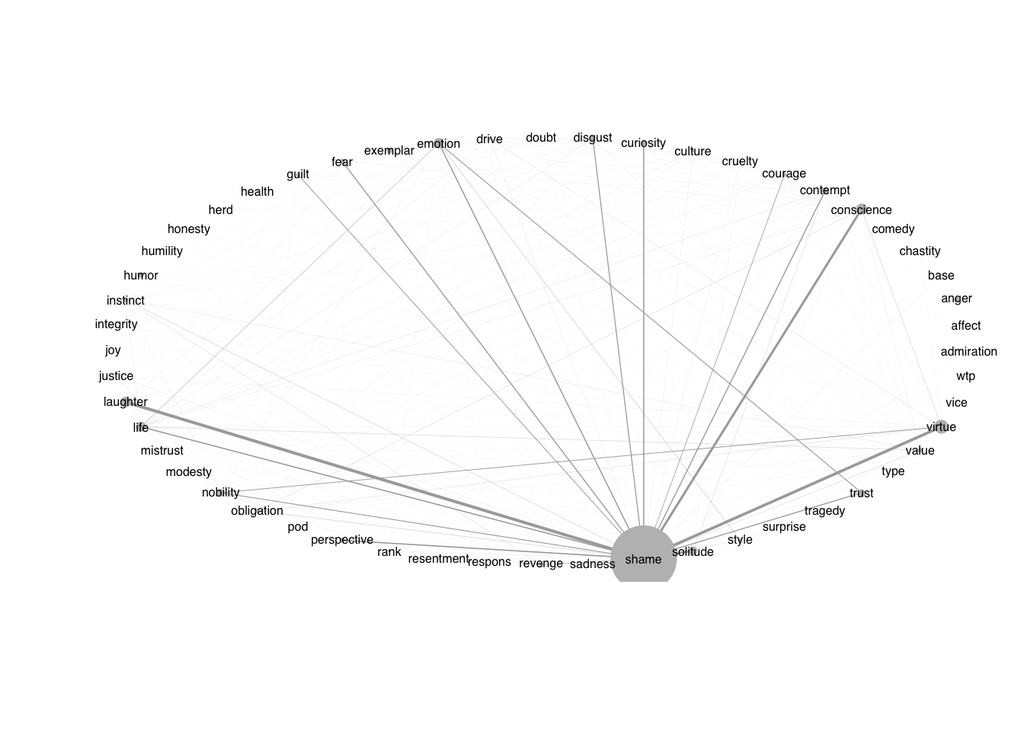

```r
l <- layout_in_circle(nietzsche_shame_network)
l <- norm_coords(l,
                 ymin=-.5,
                 ymax=.5,
                 xmin=-1,
                 xmax=1)
plot.igraph(nietzsche_shame_network,
            layout=l*2,
            vertex.color="gray",
            vertex.frame.color="gray",
            vertex.label.cex=.5,
            vertex.label.color="black",
            rescale=F,
            vertex.label.family = "Helvetica")
```

## paragraph-level egonet for ‘culture’

```r
LIWCanalysis_nietzsche_para_simple$culture <- as.numeric(as.character(LIWCanalysis_nietzsche_para_simple$culture))
LIWCanalysis_culture <- subset(LIWCanalysis_nietzsche_para_simple, culture > 0)
```

```r
M <- data.matrix(LIWCanalysis_culture)
T <- t(M)
LIWCanalysis_culture_adj <- (T %*% M)

nietzsche_culture_network <- graph_from_adjacency_matrix(LIWCanalysis_culture_adj,
                                                         mode = "undirected",
                                                         weighted = TRUE,
                                                         diag = FALSE)

str <- strength(nietzsche_culture_network)
V(nietzsche_culture_network)$size <- str*.05
E(nietzsche_culture_network)$width <- E(nietzsche_culture_network)$weight*.04
```

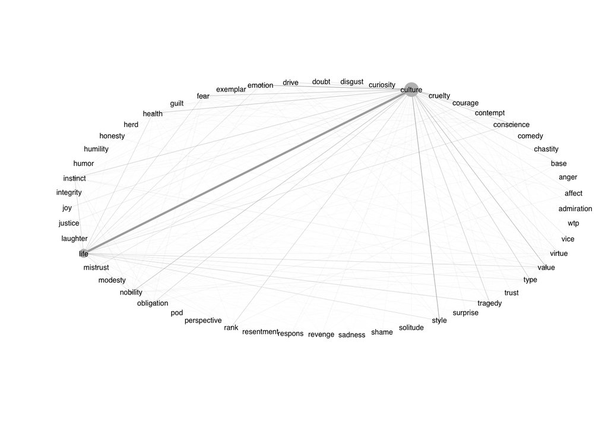

```r
l <- layout_in_circle(nietzsche_culture_network)
l <- norm_coords(l,
                 ymin=-.5,
                 ymax=.5,
                 xmin=-1,
                 xmax=1)
plot.igraph(nietzsche_culture_network,
            layout=l*2,
            vertex.color="grey",
            vertex.frame.color="grey",
            vertex.label.cex=.5,
            vertex.label.color="black",
            rescale=F,
            vertex.label.family = "Helvetica")
```

## paragraph-level egonet for ‘virtue’

Coerce the virtue column to numeric, then subset the rows so that you only have ones where virtue > 0

```r
LIWCanalysis_nietzsche_para_simple$virtue <- as.numeric(as.character(LIWCanalysis_nietzsche_para_simple$virtue))
LIWCanalysis_virtue <- subset(LIWCanalysis_nietzsche_para_simple,
                              virtue > 0)
```

```r
M <- data.matrix(LIWCanalysis_virtue)
T <- t(M)
LIWCanalysis_virtue_adj <- (T %*% M)

nietzsche_virtue_network <- graph_from_adjacency_matrix(LIWCanalysis_virtue_adj,
                                                        mode = "undirected",
                                                        weighted = TRUE,
                                                        diag = FALSE)

str <- strength(nietzsche_virtue_network)
V(nietzsche_virtue_network)$size <- str*.02
E(nietzsche_virtue_network)$width <- E(nietzsche_virtue_network)$weight*.02
```

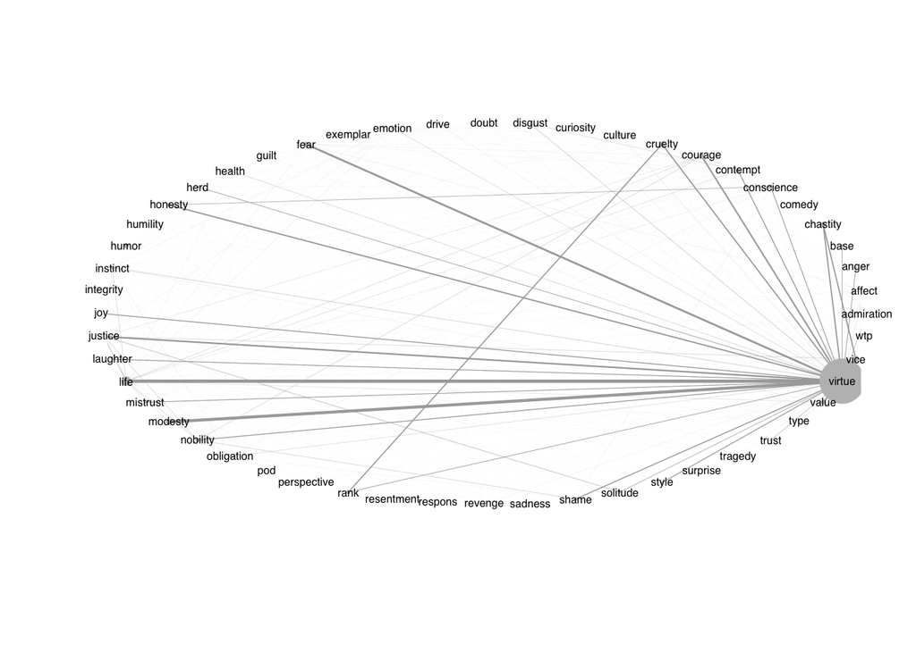

```r
l <- layout_in_circle(nietzsche_virtue_network)
l <- norm_coords(l,
                 ymin=-.5,
                 ymax=.5,
                 xmin=-1,
                 xmax=1)
plot.igraph(nietzsche_virtue_network,
            layout=l*2,
            vertex.color="grey",
            vertex.frame.color="grey",
            vertex.label.cex=.5,
            vertex.label.color="black",
            rescale=F,
            vertex.label.family = "Helvetica")
```

## bottom-up collocation analysis

### select words inside and outside desired window (10) from culture

```r
culture <- c("kultur*", "cultur*")
toks_inside <- tokens_keep(toks_nietzsche,
                           pattern = culture,
                           window = 10)
toks_inside <- tokens_remove(toks_inside, pattern = culture) # remove the keywords
toks_outside <- tokens_remove(toks_nietzsche, pattern = culture, window = 10)
```

### compare inside and outside

```r
dfmat_inside <- dfm(toks_inside)
dfmat_outside <- dfm(toks_outside)

tstat_key_inside <- textstat_keyness(rbind(dfmat_inside, dfmat_outside),
                                     target = seq_len(ndoc(dfmat_inside)))
head(tstat_key_inside, 50)
```

```
##              feature      chi2            p n_target n_reference
## 1          gekreuzte 137.26461 0.000000e+00        3           0
## 2             pforte 129.32682 0.000000e+00        5           5
## 3                der 115.11492 0.000000e+00      531       22225
## 4           barbarei 107.40806 0.000000e+00        7          17
## 5         burckhardt 101.70613 0.000000e+00        3           1
## 6       halbbarbarei  80.37708 0.000000e+00        3           2
## 7            höheren  77.88923 0.000000e+00       21         227
## 8             höhere  77.42607 0.000000e+00       16         138
## 9    feuilletonisten  73.82400 0.000000e+00        2           0
## 10             jakob  73.82400 0.000000e+00        2           0
## 11         deutschen  60.07161 9.103829e-15       29         488
## 12            höhern  56.01394 7.194245e-14        3           4
## 13           stätten  56.01394 7.194245e-14        3           4
## 14 zurückgebliebener  56.01394 7.194245e-14        3           4
```

[output cut: 36 more lines]

### select words inside and outside desired window (10) from tugend

```r
virtue <- c("tugend*")
toks_inside <- tokens_keep(toks_nietzsche, pattern = virtue, window = 10)
toks_inside <- tokens_remove(toks_inside, pattern = virtue) # remove the keywords
toks_outside <- tokens_remove(toks_nietzsche, pattern = virtue, window = 10)
```

### compare inside and outside

```r
dfmat_inside <- dfm(toks_inside)
dfmat_outside <- dfm(toks_outside)

tstat_key_inside <- textstat_keyness(rbind(dfmat_inside, dfmat_outside),
                                     target = seq_len(ndoc(dfmat_inside)))
head(tstat_key_inside, 50)
```

```
##              feature      chi2            p n_target n_reference
## 1              eurer 202.10147 0.000000e+00       19          78
## 2         erreichbar 135.59208 0.000000e+00        3           0
## 3             tiktak 111.12359 0.000000e+00        4           3
## 4         anstellige 100.45183 0.000000e+00        3           1
## 5              diene  84.90466 0.000000e+00        4           5
## 6        unmöglichen  79.37378 0.000000e+00        3           2
## 7             fäuste  72.92084 0.000000e+00        2           0
## 8    prokrustes-bett  72.92084 0.000000e+00        2           0
## 9  renaissance-stile  72.92084 0.000000e+00        2           0
## 10          untugend  72.92084 0.000000e+00        2           0
## 11        verflogene  72.92084 0.000000e+00        2           0
## 12             virtù  72.92084 0.000000e+00        2           0
## 13              eure  71.35384 0.000000e+00       17         163
## 14     gerechtigkeit  65.45064 5.551115e-16       16         156
```

[output cut: 36 more lines]